# Praca domowa 2 - MIOWAD

```python
import pandas as pd
import numpy as np
import matplotlib.pyplot as plt
```

```python
from NeuralNetwork.NeuralNetwork import Net, mse
from NeuralNetwork.Layers import DenseNetLayer
from NeuralNetwork.ActivationFunctions import SigmoidFunction, LinearFunction
from NeuralNetwork.Initializers import RandomNormalInitializer
from NeuralNetwork.Optimizers import SGD
```

## Zbiór square-simple

```python
df = pd.read_csv("./data/regression/square-simple-training.csv", index_col=0)
df.head()
```

|  | x | y |
| --- | --- | --- |
| 1 | -0.171543 | -127.351580 |
| 2 | 0.025201 | -129.942844 |
| 3 | -1.368991 | 38.672367 |
| 4 | 1.907390 | 197.432191 |
| 5 | 0.011129 | -129.988852 |

```python
X = df.x.to_numpy()
X = np.transpose(np.array([X]))
Y = df.y.to_numpy()
Y = np.transpose(np.array([Y]))
```

```python
df1 = pd.read_csv("./data/regression/square-simple-test.csv", index_col=0)
df1.head()
```

|  | x | y |
| --- | --- | --- |
| 1 | -0.980437 | -43.486918 |
| 2 | -1.219074 | 3.752808 |
| 3 | 0.124243 | -128.610721 |
| 4 | 1.227789 | 5.671828 |
| 5 | 1.067348 | -27.469169 |

```python
X1 = df1.x.to_numpy()
X1 = np.transpose(np.array([X1]))
Y1 = df1.y.to_numpy()
Y1 = np.transpose(np.array([Y1]))
```

```python
np.random.seed(0)
```

```python
n = Net(optimizer = SGD(learning_rate=0.0001))
n.add_layer(DenseNetLayer(1, 5, SigmoidFunction(), RandomNormalInitializer()))
n.add_layer(DenseNetLayer(5, 5, SigmoidFunction(), RandomNormalInitializer()))
n.add_layer(DenseNetLayer(5, 1, LinearFunction(), RandomNormalInitializer()))
n.train(X, Y, X1, Y1, n_epochs=2500, eval_frequency=100)
```

```
Epoch: 0, mse train: 9873.515301896203, mse eval: 8400.40736004786
Epoch: 100, mse train: 260.2762329760073, mse eval: 236.24516921946702
Epoch: 200, mse train: 44.53096570817196, mse eval: 50.71178553774319
Epoch: 300, mse train: 14.294268149266212, mse eval: 21.698171893480136
Epoch: 400, mse train: 8.066770036175242, mse eval: 14.353303007898893
Epoch: 500, mse train: 6.45216306918566, mse eval: 11.770340818192892
Epoch: 600, mse train: 5.586475288015021, mse eval: 10.294990691913753
Epoch: 700, mse train: 4.99715841648662, mse eval: 9.263423900136825
Epoch: 800, mse train: 4.609427768025371, mse eval: 8.510110553249634
Epoch: 900, mse train: 4.362296054314799, mse eval: 7.939157198036844
Epoch: 1000, mse train: 4.194530858175921, mse eval: 7.478959288327855
Epoch: 1100, mse train: 4.055098159029548, mse eval: 7.077591263334089
Epoch: 1200, mse train: 3.9111092507040586, mse eval: 6.70311341026872
Epoch: 1300, mse train: 3.74820848179139, mse eval: 6.340542161684382
Epoch: 1400, mse train: 3.5647580060991326, mse eval: 5.98564025163438
Epoch: 1500, mse train: 3.365241037297855, mse eval: 5.639211288778132
Epoch: 1600, mse train: 3.1559792002936176, mse eval: 5.303698748162653
Epoch: 1700, mse train: 2.9431557791436855, mse eval: 4.981697057079042
Epoch: 1800, mse train: 2.73215722076719, mse eval: 4.6754674621531045
Epoch: 1900, mse train: 2.527453516747124, mse eval: 4.386833366476072
Epoch: 2000, mse train: 2.3326096869109723, mse eval: 4.117152545495168
Epoch: 2100, mse train: 2.1502759356436583, mse eval: 3.8672647177582764
Epoch: 2200, mse train: 1.9821520724745192, mse eval: 3.6374233501211655
Epoch: 2300, mse train: 1.8289882605047398, mse eval: 3.4272666196085577
Epoch: 2400, mse train: 1.6906780875452998, mse eval: 3.23587238633237
Training result:    mse train: 1.5676236215800095     mse eval: 3.0635556792758267
```

### Wizualizacja zbioru testowego i predykcji na zbiorze testowym

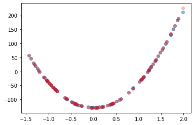

```python
plt.scatter(X1, n.forward(X1), alpha = 0.5)
plt.scatter(X1, Y1, color='red', alpha = 0.25)
plt.show()
```

```python
print(f"MSE na zbiorze testowym wynosi: {mse(Y1, n.forward(X1))}")
```

```
MSE na zbiorze testowym wynosi: 3.0635556792758267
```

## Zbiór steps-small

```python
import pandas as pd
import numpy as np
import matplotlib.pyplot as plt
```

```python
from NeuralNetwork.NeuralNetwork import Net, mse
from NeuralNetwork.Layers import DenseNetLayer
from NeuralNetwork.ActivationFunctions import SigmoidFunction, LinearFunction
from NeuralNetwork.Initializers import RandomNormalInitializer
from NeuralNetwork.Optimizers import SGD
```

```python
df = pd.read_csv("./data/regression/steps-small-training.csv", index_col=0)
X = df.x.to_numpy()
X = np.transpose(np.array([X]))
Y = df.y.to_numpy()
Y = np.transpose(np.array([Y]))

df1 = pd.read_csv("./data/regression/steps-small-test.csv", index_col=0)
X1 = df1.x.to_numpy()
X1 = np.transpose(np.array([X1]))
Y1 = df1.y.to_numpy()
Y1 = np.transpose(np.array([Y1]))
```

```python
np.random.seed(0)
```

```python
n = Net(optimizer = SGD(learning_rate=0.0001))
n.add_layer(DenseNetLayer(1, 5, SigmoidFunction(), RandomNormalInitializer()))
n.add_layer(DenseNetLayer(5, 5, SigmoidFunction(), RandomNormalInitializer()))
n.add_layer(DenseNetLayer(5, 1, LinearFunction(), RandomNormalInitializer()))
n.train(X, Y, X1, Y1, 5000, 100)
```

```
Epoch: 0, mse train: 6703.2079401452165, mse eval: 8139.181210797073
Epoch: 100, mse train: 610.2738798429514, mse eval: 763.777852058983
Epoch: 200, mse train: 390.19069488106123, mse eval: 487.57742779718967
Epoch: 300, mse train: 302.89857412730265, mse eval: 375.7814118210764
Epoch: 400, mse train: 214.9587251896597, mse eval: 278.732054832763
Epoch: 500, mse train: 159.44902534274638, mse eval: 228.40032507766384
Epoch: 600, mse train: 125.73793886598125, mse eval: 201.08190034732795
Epoch: 700, mse train: 102.69938227573422, mse eval: 182.15940639999732
Epoch: 800, mse train: 85.27921500304683, mse eval: 167.19666209337657
Epoch: 900, mse train: 71.65096720026239, mse eval: 155.53904573632374
Epoch: 1000, mse train: 60.77371535162736, mse eval: 146.4943715428948
Epoch: 1100, mse train: 51.842588779189526, mse eval: 139.24956549701847
Epoch: 1200, mse train: 44.397429507365, mse eval: 133.32446702422274
Epoch: 1300, mse train: 38.22183871845647, mse eval: 128.54626249382562
Epoch: 1400, mse train: 33.151748772238335, mse eval: 124.79823175744042
Epoch: 1500, mse train: 29.005359798590458, mse eval: 121.90962631386432
Epoch: 1600, mse train: 25.60092766407735, mse eval: 119.68392754967397
Epoch: 1700, mse train: 22.782779149809254, mse eval: 117.94671533420953
Epoch: 1800, mse train: 20.428830944172024, mse eval: 116.56534967259898
Epoch: 1900, mse train: 18.445825079240095, mse eval: 115.44627066134677
Epoch: 2000, mse train: 16.762026003637736, mse eval: 114.5249133050505
Epoch: 2100, mse train: 15.321448230632766, mse eval: 113.75628094595574
Epoch: 2200, mse train: 14.0799251183535, mse eval: 113.10821099253519
Epoch: 2300, mse train: 13.002382896103047, mse eval: 112.55700770465893
Epoch: 2400, mse train: 12.060829820128802, mse eval: 112.08469684600948
Epoch: 2500, mse train: 11.232814010595362, mse eval: 111.67730228759038
Epoch: 2600, mse train: 10.500227715374859, mse eval: 111.32374566072596
Epoch: 2700, mse train: 9.848380652085234, mse eval: 111.01512068819258
Epoch: 2800, mse train: 9.26528262470078, mse eval: 110.74419359744874
Epoch: 2900, mse train: 8.741087328324614, mse eval: 110.5050435359179
Epoch: 3000, mse train: 8.267659636622891, mse eval: 110.29279389956278
Epoch: 3100, mse train: 7.8382375248859795, mse eval: 110.10340617345523
Epoch: 3200, mse train: 7.447166771178729, mse eval: 109.93351902220961
Epoch: 3300, mse train: 7.089691853519656, mse eval: 109.78032136114362
Epoch: 3400, mse train: 6.761790398068938, mse eval: 109.64145152359424
Epoch: 3500, mse train: 6.460041489943881, mse eval: 109.51491672318559
Epoch: 3600, mse train: 6.181520400804363, mse eval: 109.39902841658171
Epoch: 3700, mse train: 5.923713999548229, mse eval: 109.29235018714313
Epoch: 3800, mse train: 5.684452423015988, mse eval: 109.19365553097475
Epoch: 3900, mse train: 5.461853586893859, mse eval: 109.10189350663445
Epoch: 4000, mse train: 5.254277884882133, mse eval: 109.01616065570475
Epoch: 4100, mse train: 5.060291012190998, mse eval: 108.93567794516598
Epoch: 4200, mse train: 4.878633300378891, mse eval: 108.85977174862644
Epoch: 4300, mse train: 4.708194297304467, mse eval: 108.78785808979805
Epoch: 4400, mse train: 4.547991593486554, mse eval: 108.71942953246602
Epoch: 4500, mse train: 4.397153103373131, mse eval: 108.65404422647487
Epoch: 4600, mse train: 4.254902171184803, mse eval: 108.59131671763201
Epoch: 4700, mse train: 4.120544996923598, mse eval: 108.53091020692005
Epoch: 4800, mse train: 3.993459976964073, mse eval: 108.4725300050888
Epoch: 4900, mse train: 3.8730886315771538, mse eval: 108.41591797744178
Training result:
    mse train: 3.7600402483362747
    mse eval: 108.36139155435876
```

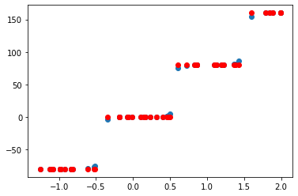

```python
plt.scatter(X, n.forward(X))
plt.scatter(X, Y, color='red')
plt.show()
```

### Wizualizacja zbioru testowego i predykcji na zbiorze testowym

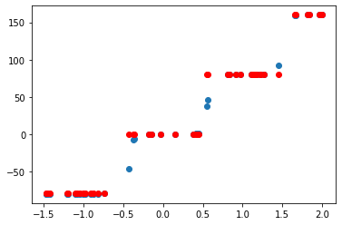

```python
plt.scatter(X1, n.forward(X1))
plt.scatter(X1, Y1, color='red')
plt.show()
```

```python
print(f"MSE na zbiorze treningowym wynosi: {mse(Y, n.forward(X))}")
```

```
MSE na zbiorze treningowym wynosi: 3.7600402483362747
```

```python
print(f"MSE na zbiorze testowym wynosi: {mse(Y1, n.forward(X1))}")
```

```
MSE na zbiorze testowym wynosi: 108.36139155435876
```

Sieć powyżej nie mogła się nauczyć, aby MSE na zbiorze testowym spadło do poziomu 4.

Wynika to z tego, że w zbiorze testowym znajdują się punkty, które znajdują się pomiędzy punktami w zbiorze treningowym, które są na różnych poziomach. Nic zatem dziwnego, że te punkty dostają predykcję pomiędzy skokami.

Jednakże, jeśli do zbioru treningowego dodamy dwa punkty:

`"51",-0.432491056621075,0`

`"52",0.551153895677999,80`

to sytuacja wygląda jak poniżej, czyli sieć się bardzo dobrze dopasowuje, a mse na zbiorze testowym osiąga wartość poniżej 4.

#### Steps-small z dwoma dodanymi punktami do zbioru treningowego

```python
import pandas as pd
import numpy as np
import matplotlib.pyplot as plt
```

```python
from NeuralNetwork.NeuralNetwork import Net, mse
from NeuralNetwork.Layers import DenseNetLayer
from NeuralNetwork.ActivationFunctions import SigmoidFunction, LinearFunction
from NeuralNetwork.Initializers import RandomNormalInitializer
from NeuralNetwork.Optimizers import SGD
```

```python
df = pd.read_csv("./data/regression/steps-small-training-modified.csv", index_col=0)
X = df.x.to_numpy()
X = np.transpose(np.array([X]))
Y = df.y.to_numpy()
Y = np.transpose(np.array([Y]))

df1 = pd.read_csv("./data/regression/steps-small-test.csv", index_col=0)
X1 = df1.x.to_numpy()
X1 = np.transpose(np.array([X1]))
Y1 = df1.y.to_numpy()
Y1 = np.transpose(np.array([Y1]))
```

```python
np.random.seed(0)
```

```python
n = Net(optimizer = SGD(learning_rate=0.0001))
n.add_layer(DenseNetLayer(1, 5, SigmoidFunction(), RandomNormalInitializer()))
n.add_layer(DenseNetLayer(5, 5, SigmoidFunction(), RandomNormalInitializer()))
n.add_layer(DenseNetLayer(5, 1, LinearFunction(), RandomNormalInitializer()))
n.train(X, Y, X1, Y1, 5000, 100)
```

```
Epoch: 0, mse train: 6571.34983308913, mse eval: 8135.074075003786
Epoch: 100, mse train: 678.4826247193382, mse eval: 748.5597632447054
Epoch: 200, mse train: 472.07539821768154, mse eval: 461.6419418379031
Epoch: 300, mse train: 381.58817670193423, mse eval: 342.6101254037623
Epoch: 400, mse train: 298.1762002178451, mse eval: 233.35440945863536
Epoch: 500, mse train: 244.4285694765929, mse eval: 172.96757581709724
Epoch: 600, mse train: 210.20243702752302, mse eval: 138.1818521909641
Epoch: 700, mse train: 184.9546616646248, mse eval: 113.54131050464107
Epoch: 800, mse train: 164.55977894204165, mse eval: 94.06019167262326
Epoch: 900, mse train: 147.50926196135939, mse eval: 78.5093646517517
Epoch: 1000, mse train: 132.7899914405284, mse eval: 66.06052042397856
Epoch: 1100, mse train: 119.72522527493949, mse eval: 55.926211792237844
Epoch: 1200, mse train: 108.0339552700332, mse eval: 47.57723612000662
Epoch: 1300, mse train: 97.64228124925327, mse eval: 40.737138797338886
Epoch: 1400, mse train: 88.47615667300138, mse eval: 35.2014566583842
Epoch: 1500, mse train: 80.40174093848911, mse eval: 30.743314751297426
Epoch: 1600, mse train: 73.25805504620156, mse eval: 27.131242476113233
Epoch: 1700, mse train: 66.89235069759523, mse eval: 24.167142962962107
Epoch: 1800, mse train: 61.170875550870775, mse eval: 21.700154632402185
Epoch: 1900, mse train: 55.97670881038151, mse eval: 19.621505892863834
Epoch: 2000, mse train: 51.20658428324771, mse eval: 17.85385452444742
Epoch: 2100, mse train: 46.76985289896247, mse eval: 16.34178200100333
Epoch: 2200, mse train: 42.58957271348907, mse eval: 15.044942678363505
Epoch: 2300, mse train: 38.60680139450073, mse eval: 13.933448486986904
Epoch: 2400, mse train: 34.79076527985323, mse eval: 12.98446368461422
Epoch: 2500, mse train: 31.15524113943919, mse eval: 12.178695219907281
Epoch: 2600, mse train: 27.768096115253723, mse eval: 11.496060769593539
Epoch: 2700, mse train: 24.725637992106538, mse eval: 10.912715890617738
Epoch: 2800, mse train: 22.093571154597246, mse eval: 10.403419065864533
Epoch: 2900, mse train: 19.87248074840013, mse eval: 9.947286881620466
Epoch: 3000, mse train: 18.014688714986615, mse eval: 9.530495375169574
Epoch: 3100, mse train: 16.45671509047928, mse eval: 9.144937842552137
Epoch: 3200, mse train: 15.139078052284553, mse eval: 8.785874240778337
Epoch: 3300, mse train: 14.012843720143865, mse eval: 8.450278319049382
Epoch: 3400, mse train: 13.039779396827619, mse eval: 8.13596625735559
Epoch: 3500, mse train: 12.19051329252509, mse eval: 7.841185822638351
Epoch: 3600, mse train: 11.442491750701892, mse eval: 7.564428220009921
Epoch: 3700, mse train: 10.778269512683847, mse eval: 7.304341606688144
Epoch: 3800, mse train: 10.18420649517477, mse eval: 7.059690855758894
Epoch: 3900, mse train: 9.649508921208325, mse eval: 6.829338268693359
Epoch: 4000, mse train: 9.165531262688157, mse eval: 6.612233441108999
Epoch: 4100, mse train: 8.725267424987718, mse eval: 6.4074068178460815
Epoch: 4200, mse train: 8.322977241574073, mse eval: 6.213964533529617
Epoch: 4300, mse train: 7.953909588015657, mse eval: 6.031083590431184
Epoch: 4400, mse train: 7.614094853776313, mse eval: 5.858007079265736
Epoch: 4500, mse train: 7.300187630019095, mse eval: 5.694039414489144
Epoch: 4600, mse train: 7.009346123335785, mse eval: 5.538541644833964
Epoch: 4700, mse train: 6.739138718366328, mse eval: 5.39092691450463
Epoch: 4800, mse train: 6.487470827678328, mse eval: 5.250656137721585
Epoch: 4900, mse train: 6.25252706319315, mse eval: 5.117233929442509
Training result:
    mse train: 6.03485286465342
    mse eval: 4.991444866098952
```

```python
n.train(X, Y, X1, Y1, 200, 100)
```

```
Epoch: 0, mse train: 6.032725098179369, mse eval: 4.9902048162495936
Epoch: 100, mse train: 5.826678537263533, mse eval: 4.869149736205397
Training result:
    mse train: 5.635043513227185
    mse eval: 4.754811024357673
```

```python
n.train(X, Y, X1, Y1, 1000, 100)
```

```
Epoch: 0, mse train: 5.633166792520269, mse eval: 4.753682825343627
Epoch: 100, mse train: 5.451110456965295, mse eval: 4.643448480847067
Epoch: 200, mse train: 5.279551027825093, mse eval: 4.5381186861644105
Epoch: 300, mse train: 5.11763409876451, mse eval: 4.4373905806075955
Epoch: 400, mse train: 4.964595339270966, mse eval: 4.340984254743574
Epoch: 500, mse train: 4.819748729176822, mse eval: 4.248640752713824
Epoch: 600, mse train: 4.6824766300005525, mse eval: 4.160120263082443
Epoch: 700, mse train: 4.55222136180063, mse eval: 4.075200480732452
Epoch: 800, mse train: 4.4284780213541195, mse eval: 3.99367512345743
Epoch: 900, mse train: 4.310788329619895, mse eval: 3.9153525881669067
Training result:
    mse train: 4.199829242300895
    mse eval: 3.840793293377812
```

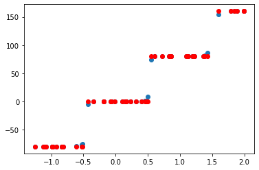

```python
plt.scatter(X, n.forward(X))
plt.scatter(X, Y, color='red')
plt.show()
```

### Wizualizacja zbioru testowego i predykcji na zbiorze testowym

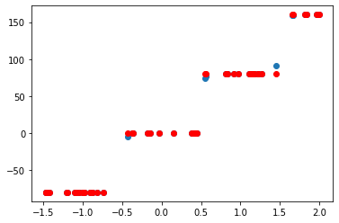

```python
plt.scatter(X1, n.forward(X1))
plt.scatter(X1, Y1, color='red')
plt.show()
```

```python
print(f"MSE na zbiorze testowym wynosi: {mse(Y1, n.forward(X1))}")
```

```
MSE na zbiorze testowym wynosi: 3.840793293377812
```

## Zbiór multimodal-large

```python
import pandas as pd
import numpy as np
import matplotlib.pyplot as plt

from NeuralNetwork.NeuralNetwork import Net, mse
from NeuralNetwork.Layers import DenseNetLayer
from NeuralNetwork.ActivationFunctions import SigmoidFunction, LinearFunction
from NeuralNetwork.Initializers import RandomNormalInitializer
from NeuralNetwork.Optimizers import SGD, GradientDescentBatch
```

```python
df = pd.read_csv("./data/regression/multimodal-large-training.csv")
df.head()
X = df.x.to_numpy()
X = np.transpose(np.array([X]))
Y = df.y.to_numpy()
Y = np.transpose(np.array([Y]))

df1 = pd.read_csv("./data/regression/multimodal-large-test.csv")
df1.head()
X1 = df1.x.to_numpy()
X1 = np.transpose(np.array([X1]))
Y1 = df1.y.to_numpy()
Y1 = np.transpose(np.array([Y1]))
```

```python
np.random.seed(0)
n1 = Net(optimizer = GradientDescentBatch(learning_rate=0.00001, batch_size=64))
n1.add_layer(DenseNetLayer(1, 20, SigmoidFunction(), RandomNormalInitializer()))
n1.add_layer(DenseNetLayer(20, 5, SigmoidFunction(), RandomNormalInitializer()))
n1.add_layer(DenseNetLayer(5, 1, LinearFunction(), RandomNormalInitializer()))
n1.train(X, Y, X1, Y1, 100, 10)
```

```
Epoch: 0, mse train: 5131.097317205889, mse eval: 5176.673155503554
Epoch: 10, mse train: 2212.165094328029, mse eval: 2260.6323059691276
Epoch: 20, mse train: 1780.0871757235934, mse eval: 1801.6287252303698
Epoch: 30, mse train: 1550.2118213004478, mse eval: 1566.8189515544889
Epoch: 40, mse train: 1496.1835190566012, mse eval: 1511.4717774590408
Epoch: 50, mse train: 1480.4003356530977, mse eval: 1495.6885887042638
Epoch: 60, mse train: 1452.018474353806, mse eval: 1477.233288357692
Epoch: 70, mse train: 864.653946317667, mse eval: 905.3595894392727
Epoch: 80, mse train: 612.9848722458863, mse eval: 642.1097148361595
Epoch: 90, mse train: 420.5321879782074, mse eval: 459.2827225047249
Training result:
    mse train: 366.99959048988063
    mse eval: 407.0447984798768
```

```python
n1.train(X, Y, X1, Y1, 100, 10)
```

```
Epoch: 0, mse train: 366.112700811959, mse eval: 406.1528746508397
Epoch: 10, mse train: 364.5873249599401, mse eval: 404.3725319538366
Epoch: 20, mse train: 365.55270062726566, mse eval: 405.02604034619986
Epoch: 30, mse train: 365.1941300019297, mse eval: 404.4594271791191
Epoch: 40, mse train: 363.76064993529815, mse eval: 402.8508800715908
Epoch: 50, mse train: 361.99074997206685, mse eval: 400.9702691371719
Epoch: 60, mse train: 359.70986047145186, mse eval: 398.6846707519817
Epoch: 70, mse train: 354.61198728350934, mse eval: 393.7302337460221
Epoch: 80, mse train: 342.22841824662913, mse eval: 381.0403463226949
Epoch: 90, mse train: 328.15819404234725, mse eval: 365.6410076067416
Training result:
    mse train: 311.39582435295006
    mse eval: 345.52812063819005
```

```python
n1.train(X, Y, X1, Y1, 100, 10)
```

```
Epoch: 0, mse train: 309.10576801678974, mse eval: 342.7237566758646
Epoch: 10, mse train: 285.7925888753196, mse eval: 313.607821205799
Epoch: 20, mse train: 265.1515112282659, mse eval: 286.8747432976136
Epoch: 30, mse train: 244.59989942815295, mse eval: 260.9934651118939
Epoch: 40, mse train: 222.9920234759293, mse eval: 235.86667992054356
Epoch: 50, mse train: 200.89430072444495, mse eval: 212.1251966227569
Epoch: 60, mse train: 179.855297960779, mse eval: 190.27748258532367
Epoch: 70, mse train: 160.92799846004945, mse eval: 170.29214235911493
Epoch: 80, mse train: 144.08510477396985, mse eval: 152.0196472042521
Epoch: 90, mse train: 127.69880284900648, mse eval: 135.71502155506954
Training result:
    mse train: 120.24873541644928
    mse eval: 129.7220836239288
```

```python
n1.train(X, Y, X1, Y1, 100, 10)
```

```
Epoch: 0, mse train: 119.11721077118563, mse eval: 128.50852285347258
Epoch: 10, mse train: 106.88070600831045, mse eval: 115.08140106961665
Epoch: 20, mse train: 94.55971301212824, mse eval: 101.43019929721318
Epoch: 30, mse train: 83.22530741136895, mse eval: 88.85769683179204
Epoch: 40, mse train: 73.29410007529185, mse eval: 77.86866162294038
Epoch: 50, mse train: 64.95045824375039, mse eval: 68.65396462007384
Epoch: 60, mse train: 58.15656259512919, mse eval: 61.134256005763945
Epoch: 70, mse train: 52.60013420426098, mse eval: 54.938968872676554
Epoch: 80, mse train: 47.840392705684785, mse eval: 49.57845285584312
Epoch: 90, mse train: 43.51592125321509, mse eval: 44.66724045500794
Training result:
    mse train: 39.866931352625144
    mse eval: 40.50160625524599
```

```python
n1.train(X, Y, X1, Y1, 100, 10)
```

```
Epoch: 0, mse train: 39.47515915542461, mse eval: 40.05341303482493
Epoch: 10, mse train: 35.72428311443784, mse eval: 35.753659703224294
Epoch: 20, mse train: 32.311103833798214, mse eval: 31.827039821435946
Epoch: 30, mse train: 29.26538203507521, mse eval: 28.310493488264996
Epoch: 40, mse train: 26.588748867050523, mse eval: 25.208145768543
Epoch: 50, mse train: 24.262231603118387, mse eval: 22.500206468876602
Epoch: 60, mse train: 22.255856465920534, mse eval: 20.15410195492938
Epoch: 70, mse train: 20.53566552073698, mse eval: 18.13253987936321
Epoch: 80, mse train: 19.06777561961761, mse eval: 16.398145322071027
Epoch: 90, mse train: 17.820451042479842, mse eval: 14.915816936246062
Training result:
    mse train: 16.862645142656703
    mse eval: 13.770845872069446
```

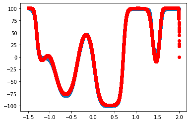

```python
plt.scatter(X, n1.forward(X))
plt.scatter(X, Y, color='red')
plt.show()
```

### Wizualizacja zbioru testowego i predykcji na zbiorze testowym

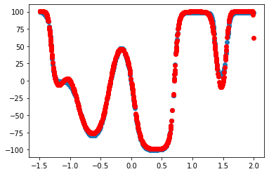

```python
plt.scatter(X1, n1.forward(X1))
plt.scatter(X1, Y1, color='red')
plt.show()
```

```python
print(f"MSE na zbiorze testowym wynosi: {mse(Y1, n1.forward(X1))}")
```

```
MSE na zbiorze testowym wynosi: 13.770845872069446
```

## Wizualizacja zmiany wartości wag w kolejnych iteracjach

### Zbiór square-simple

```python
import pandas as pd
import numpy as np
import matplotlib.pyplot as plt
```

```python
from NeuralNetwork.NeuralNetwork import Net, mse
from NeuralNetwork.Layers import DenseNetLayer
from NeuralNetwork.ActivationFunctions import SigmoidFunction, LinearFunction
from NeuralNetwork.Initializers import RandomNormalInitializer
from NeuralNetwork.Optimizers import SGD
```

```python
df = pd.read_csv("./data/regression/square-simple-training.csv", index_col=0)

X = df.x.to_numpy()
X = np.transpose(np.array([X]))
Y = df.y.to_numpy()
Y = np.transpose(np.array([Y]))

df1 = pd.read_csv("./data/regression/square-simple-test.csv", index_col=0)

X1 = df1.x.to_numpy()
X1 = np.transpose(np.array([X1]))
Y1 = df1.y.to_numpy()
Y1 = np.transpose(np.array([Y1]))
```

```python
np.random.seed(0)
```

Na wykresach przedstawiona jest wartość normy Frobeniusa wag i biasów dla każdej z warstw w kolejnych epokach

```
Training result:
    mse train: 4.195996669743907
    mse eval: 7.483200282629786
```

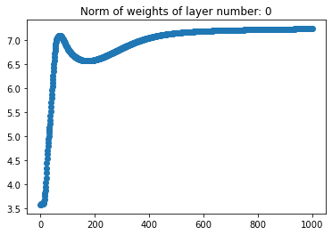

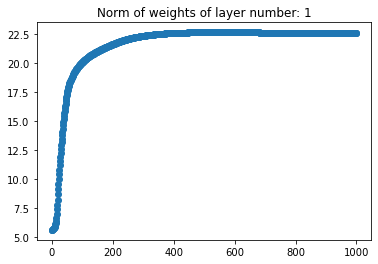

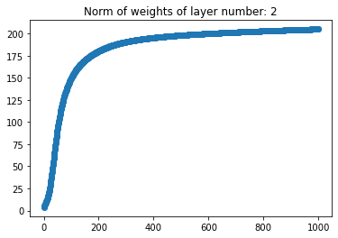

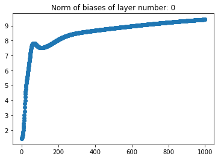

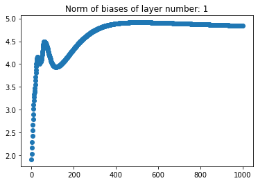

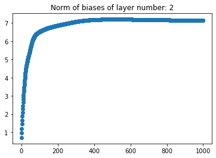

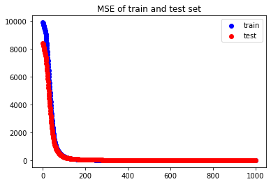

```python
n = Net(optimizer = SGD(learning_rate=0.0001))
n.add_layer(DenseNetLayer(1, 5, SigmoidFunction(), RandomNormalInitializer()))
n.add_layer(DenseNetLayer(5, 5, SigmoidFunction(), RandomNormalInitializer()))
n.add_layer(DenseNetLayer(5, 1, LinearFunction(), RandomNormalInitializer()))
n.train_and_visualize(X, Y, X1, Y1, n_epochs=1000, eval_frequency=1)
```

### Zbiór square-simple - nieudany trening

```python
import pandas as pd
import numpy as np
import matplotlib.pyplot as plt
```

```python
from NeuralNetwork.NeuralNetwork import Net, mse
from NeuralNetwork.Layers import DenseNetLayer
from NeuralNetwork.ActivationFunctions import SigmoidFunction, LinearFunction
from NeuralNetwork.Initializers import RandomNormalInitializer
from NeuralNetwork.Optimizers import SGD
```

```python
df = pd.read_csv("./data/regression/square-simple-training.csv", index_col=0)

X = df.x.to_numpy()
X = np.transpose(np.array([X]))
Y = df.y.to_numpy()
Y = np.transpose(np.array([Y]))

df1 = pd.read_csv("./data/regression/square-simple-test.csv", index_col=0)

X1 = df1.x.to_numpy()
X1 = np.transpose(np.array([X1]))
Y1 = df1.y.to_numpy()
Y1 = np.transpose(np.array([Y1]))
```

```python
np.random.seed(0)
```

```
Training result:
    mse train: 9309.88573624652
    mse eval: 7618.593128410928
```

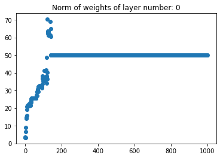

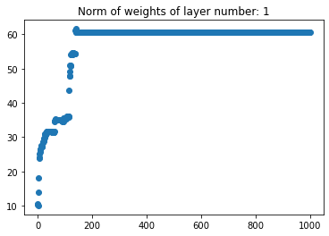

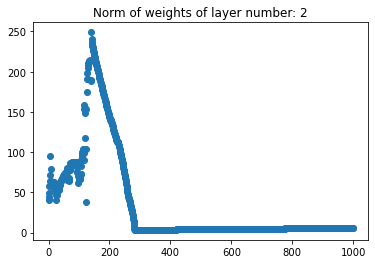

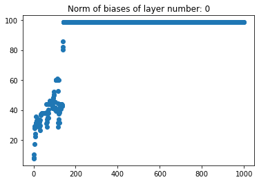

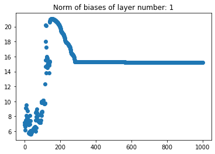

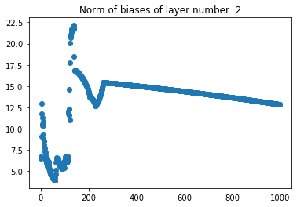

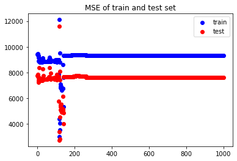

```python
n = Net(optimizer = SGD(learning_rate=0.005))
n.add_layer(DenseNetLayer(1, 5, SigmoidFunction(), RandomNormalInitializer()))
n.add_layer(DenseNetLayer(5, 5, SigmoidFunction(), RandomNormalInitializer()))
n.add_layer(DenseNetLayer(5, 1, LinearFunction(), RandomNormalInitializer()))
n.train_and_visualize(X, Y, X1, Y1, n_epochs=1000, eval_frequency=1)
```

Najprawdopodobniej przyczyną niepowodzenia treningu jest zbyt duża wartość learning rate

Wykresy norm wag i biasów są mocno "poszarpane", co oznacza, że następowały znaczne i gwałtowne zmiany w ich wartościach

W rezultacie, algorytm mógł "zgubić" optymalne wagi za sobą wykonując zbyt duże skoki

Dodatkowo, w pewnym momencie wagi praktycznie przestają się zmieniać (oprócz biasu warstwy drugiej) i w efekcie mse również się nie zmienia

### Trenowanie z batchami - zbiór square-simple

```python
import pandas as pd
import numpy as np
import matplotlib.pyplot as plt
```

```python
from NeuralNetwork.NeuralNetwork import Net, mse
from NeuralNetwork.Layers import DenseNetLayer
from NeuralNetwork.ActivationFunctions import SigmoidFunction, LinearFunction
from NeuralNetwork.Initializers import RandomNormalInitializer
from NeuralNetwork.Optimizers import SGD
```

```python
from NeuralNetwork.Optimizers import GradientDescentBatch
```

```python
df = pd.read_csv("./data/regression/square-simple-training.csv", index_col=0)

X = df.x.to_numpy()
X = np.transpose(np.array([X]))
Y = df.y.to_numpy()
Y = np.transpose(np.array([Y]))

df1 = pd.read_csv("./data/regression/square-simple-test.csv", index_col=0)

X1 = df1.x.to_numpy()
X1 = np.transpose(np.array([X1]))
Y1 = df1.y.to_numpy()
Y1 = np.transpose(np.array([Y1]))
```

```python
def create_net(batch_size):
    np.random.seed(0)
    n = Net(optimizer = GradientDescentBatch(learning_rate=0.0001, batch_size=batch_size))
    n.add_layer(DenseNetLayer(1, 5, SigmoidFunction(), RandomNormalInitializer()))
    n.add_layer(DenseNetLayer(5, 5, SigmoidFunction(), RandomNormalInitializer()))
    n.add_layer(DenseNetLayer(5, 1, LinearFunction(), RandomNormalInitializer()))
    return n
```

```python
def train_until_mse_threshold(net, thresh):
    k = 0
    while k < 5000:
        net.optimizer.step(X, Y,
                            [layer.weights for layer in net.layers],
                            [layer.biases for layer in net.layers],
                            net.backward_step)
        mse_test = mse(Y1, net.forward(X1))
        if mse_test <= thresh:
            return k
        else:
            k += 1
```

```python
mse_thresh = 50
batch_sizes = [1, 2, 4, 8, 12, 16, 20, 24, 28, 32, 36, 40, 44, 48, 50]
number_of_epochs = [
    train_until_mse_threshold(
        create_net(size), mse_thresh) for size in batch_sizes
]
```

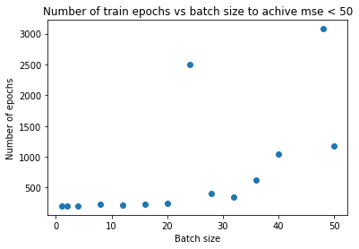

```python
plt.scatter(batch_sizes, number_of_epochs)
plt.title(f"Number of train epochs vs batch size to achive mse < {mse_thresh}")
plt.xlabel("Batch size")
plt.ylabel("Number of epochs")
plt.show()
```

Jak widać na wykresie powyżej, sieć uczyła się szybciej dla batchy o mniejszym rozmiarze.

Zauważmy, że rozmiar zbioru treningowego to 50, a zatem dla batcha rozmiaru 50 aktualizaujemy wagi po prezentacji całego zbioru treningowego.

Została również zaimplementowana metoda, która aktualizauje wagi po prezentacji całego zbioru (bez wskazywania rozmiaru batchy). Jest to optimizer o nazwie `GradientDescent` w pliku `NeuralNetwork/Optimizers.py` (do treningu z batchami używany jest optimizer `GradientDescentBatch`, natomiast optimizer `SGD` aktualizuje wagi po każdym wierszu danych).

### Metoda Xavier inicjowania wag - zbiór square-simple

```python
import pandas as pd
import numpy as np
import matplotlib.pyplot as plt
```

```python
from NeuralNetwork.NeuralNetwork import Net, mse
from NeuralNetwork.Layers import DenseNetLayer
from NeuralNetwork.ActivationFunctions import SigmoidFunction, LinearFunction
from NeuralNetwork.Initializers import XavierInitializer
from NeuralNetwork.Optimizers import SGD
```

```python
from NeuralNetwork.Initializers import XavierInitializer
```

```python
df = pd.read_csv("./data/regression/square-simple-training.csv", index_col=0)

X = df.x.to_numpy()
X = np.transpose(np.array([X]))
Y = df.y.to_numpy()
Y = np.transpose(np.array([Y]))

df1 = pd.read_csv("./data/regression/square-simple-test.csv", index_col=0)

X1 = df1.x.to_numpy()
X1 = np.transpose(np.array([X1]))
Y1 = df1.y.to_numpy()
Y1 = np.transpose(np.array([Y1]))
```

```python
np.random.seed(0)
```

```python
n = Net(optimizer = SGD(learning_rate=0.0001))
n.add_layer(DenseNetLayer(1, 5, SigmoidFunction(), XavierInitializer(1, 5)))
n.add_layer(DenseNetLayer(5, 5, SigmoidFunction(), XavierInitializer(5, 5)))
n.add_layer(DenseNetLayer(5, 1, LinearFunction(), XavierInitializer(5, 1)))
n.train(X, Y, X1, Y1, n_epochs=1000, eval_frequency=100)
```

```
Epoch: 0, mse train: 10033.937334234655, mse eval: 8603.76926738219
Epoch: 100, mse train: 3737.8967171042223, mse eval: 2690.159089404986
Epoch: 200, mse train: 2408.447255060134, mse eval: 1847.71731780186
Epoch: 300, mse train: 208.4313535029018, mse eval: 116.73212303534815
Epoch: 400, mse train: 78.31901736839198, mse eval: 52.284877758207266
Epoch: 500, mse train: 37.03138222169463, mse eval: 31.131757437472114
Epoch: 600, mse train: 19.86754216653673, mse eval: 20.784648705094774
Epoch: 700, mse train: 11.772575546160983, mse eval: 15.23792077480138
Epoch: 800, mse train: 7.508095578481467, mse eval: 12.164018591096967
Epoch: 900, mse train: 4.974036858959858, mse eval: 10.193827887376637
Training result:
    mse train: 3.5426726111448357
    mse eval: 8.838681372230244
```